# Lab2 Daniel Kwong

https://github.com/daniellkwong/GSB544.git

## 0. Import the data and declare your package dependencies.

```python
import pandas as pd
import numpy as np
import matplotlib.pyplot as plt
import seaborn as sns


data = pd.read_csv("/Users/danielkwong/Documents/GitHub/GSB544/avocado-updated-2020.csv")
```

## 1. Briefly describe the data set. What information does it contain?

This dataset is about historical data on avocado prices and sales volume in multiple cities, states, and regions of the USA. This dataset contains various information, such as average price, total volume, avacado size, and sizes of bags.

## 2. Clean the data in any way you see fit.

```python
data['geography'].unique()
```

```
array(['Albany', 'Atlanta', 'Baltimore/Washington', 'Boise', 'Boston',
       'Buffalo/Rochester', 'California', 'Charlotte', 'Chicago',
       'Cincinnati/Dayton', 'Columbus', 'Dallas/Ft. Worth', 'Denver',
       'Detroit', 'Grand Rapids', 'Great Lakes', 'Harrisburg/Scranton',
       'Hartford/Springfield', 'Houston', 'Indianapolis', 'Jacksonville',
       'Las Vegas', 'Los Angeles', 'Louisville', 'Miami/Ft. Lauderdale',
       'Midsouth', 'Nashville', 'New Orleans/Mobile', 'New York',
       'Northeast', 'Northern New England', 'Orlando', 'Philadelphia',
       'Phoenix/Tucson', 'Pittsburgh', 'Plains', 'Portland',
       'Raleigh/Greensboro', 'Richmond/Norfolk', 'Roanoke', 'Sacramento',
       'San Diego', 'San Francisco', 'Seattle', 'South Carolina',
       'South Central', 'Southeast', 'Spokane', 'St. Louis', 'Syracuse',
       'Tampa', 'Total U.S.', 'West', 'West Tex/New Mexico'], dtype=object)
```

```python
region_map = {
    # Northeast
    'Albany': 'Northeast', 'Boston': 'Northeast', 'Buffalo/Rochester': 'Northeast',
    'New York': 'Northeast', 'Philadelphia': 'Northeast', 'Baltimore/Washington': 'Northeast',
    'Hartford/Springfield': 'Northeast', 'Harrisburg/Scranton': 'Northeast',
    'Syracuse': 'Northeast', 'Northern New England': 'Northeast',
    'Northeast': 'Northeast',

    # Midwest
    'Chicago': 'Midwest', 'Detroit': 'Midwest', 'Cincinnati/Dayton': 'Midwest',
    'Columbus': 'Midwest', 'Indianapolis': 'Midwest', 'St. Louis': 'Midwest',
    'Grand Rapids': 'Midwest', 'Great Lakes': 'Midwest',
    'Plains': 'Midwest',

    # South
    'Atlanta': 'South', 'Charlotte': 'South', 'Nashville': 'South', 'Louisville': 'South',
    'Dallas/Ft. Worth': 'South', 'Houston': 'South', 'Miami/Ft. Lauderdale': 'South',
    'Tampa': 'South', 'Orlando': 'South', 'Jacksonville': 'South',
    'New Orleans/Mobile': 'South', 'Raleigh/Greensboro': 'South',
    'Richmond/Norfolk': 'South', 'Roanoke': 'South',
    'South Carolina': 'South', 'Midsouth': 'South', 'South Central': 'South',
    'Southeast': 'South',

    # West
    'Los Angeles': 'West', 'San Francisco': 'West', 'San Diego': 'West',
    'Sacramento': 'West', 'Seattle': 'West', 'Portland': 'West',
    'Spokane': 'West', 'Las Vegas': 'West', 'Phoenix/Tucson': 'West',
    'Boise': 'West', 'West Tex/New Mexico': 'West',
    'California': 'West', 'West': 'West',

    # National
    'Total U.S.': 'National'
}

data['region'] = data['geography'].map(region_map)
```

```python
market_size_map = {
    # Tier 1
    'New York': 'Tier 1',
    'Los Angeles': 'Tier 1',
    'Chicago': 'Tier 1',
    'Dallas/Ft. Worth': 'Tier 1',
    'Houston': 'Tier 1',
    'Miami/Ft. Lauderdale': 'Tier 1',
    'San Francisco': 'Tier 1',
    'Philadelphia': 'Tier 1',
    'Atlanta': 'Tier 1',
    'Boston': 'Tier 1',
    'Baltimore/Washington': 'Tier 1',
    'Phoenix/Tucson': 'Tier 1',

    # Tier 2
    'Charlotte': 'Tier 2',
    'Seattle': 'Tier 2',
    'Denver': 'Tier 2',
    'Detroit': 'Tier 2',
    'Orlando': 'Tier 2',
    'Tampa': 'Tier 2',
    'St. Louis': 'Tier 2',
    'Pittsburgh': 'Tier 2',
    'Portland': 'Tier 2',
    'Las Vegas': 'Tier 2',
    'San Diego': 'Tier 2',
    'Nashville': 'Tier 2',
    'Raleigh/Greensboro': 'Tier 2',
    'Richmond/Norfolk': 'Tier 2',

    # Tier 3
    'Albany': 'Tier 3',
    'Boise': 'Tier 3',
    'Buffalo/Rochester': 'Tier 3',
    'Grand Rapids': 'Tier 3',
    'Great Lakes': 'Tier 3',
    'Harrisburg/Scranton': 'Tier 3',
    'Hartford/Springfield': 'Tier 3',
    'Indianapolis': 'Tier 3',
    'Jacksonville': 'Tier 3',
    'Louisville': 'Tier 3',
    'New Orleans/Mobile': 'Tier 3',
    'Northern New England': 'Tier 3',
    'Roanoke': 'Tier 3',
    'Sacramento': 'Tier 3',
    'South Carolina': 'Tier 3',
    'Spokane': 'Tier 3',
    'Syracuse': 'Tier 3',
    'West Tex/New Mexico': 'Tier 3',
    'Cincinnati/Dayton': 'Tier 3',
    'Columbus': 'Tier 3',
    'Midsouth': 'Tier 3',
    'Plains': 'Tier 3',

    # Aggregates
    'California': 'Aggregate',
    'Northeast': 'Aggregate',
    'South Central': 'Aggregate',
    'Southeast': 'Aggregate',
    'West': 'Aggregate',

    # National
    'Total U.S.': 'National'
}

data['market_size'] = data['geography'].map(market_size_map)
```

```python
data = data.dropna()

data = data.rename(columns={
    '4046': 'small_hass',
    '4225': 'large_hass',
    '4770': 'xl_hass'
})

data
```

|  | date | average_price | total_volume | small_hass | large_hass | xl_hass | total_bags | small_bags | large_bags | xlarge_bags | type | year | geography | region | market_size |
| --- | --- | --- | --- | --- | --- | --- | --- | --- | --- | --- | --- | --- | --- | --- | --- |
| 0 | 2015-01-04 | 1.22 | 40873.28 | 2819.50 | 28287.42 | 49.90 | 9716.46 | 9186.93 | 529.53 | 0.00 | conventional | 2015 | Albany | Northeast | Tier 3 |
| 1 | 2015-01-04 | 1.79 | 1373.95 | 57.42 | 153.88 | 0.00 | 1162.65 | 1162.65 | 0.00 | 0.00 | organic | 2015 | Albany | Northeast | Tier 3 |
| 2 | 2015-01-04 | 1.00 | 435021.49 | 364302.39 | 23821.16 | 82.15 | 46815.79 | 16707.15 | 30108.64 | 0.00 | conventional | 2015 | Atlanta | South | Tier 1 |
| 3 | 2015-01-04 | 1.76 | 3846.69 | 1500.15 | 938.35 | 0.00 | 1408.19 | 1071.35 | 336.84 | 0.00 | organic | 2015 | Atlanta | South | Tier 1 |
| 4 | 2015-01-04 | 1.08 | 788025.06 | 53987.31 | 552906.04 | 39995.03 | 141136.68 | 137146.07 | 3990.61 | 0.00 | conventional | 2015 | Baltimore/Washington | Northeast | Tier 1 |
| ... | ... | ... | ... | ... | ... | ... | ... | ... | ... | ... | ... | ... | ... | ... | ... |
| 33040 | 2020-11-29 | 1.47 | 1583056.27 | 67544.48 | 97996.46 | 2617.17 | 1414878.10 | 906711.52 | 480191.83 | 27974.75 | organic | 2020 | Total U.S. | National | National |
| 33041 | 2020-11-29 | 0.91 | 5811114.22 | 1352877.53 | 589061.83 | 19741.90 | 3790665.29 | 2197611.02 | 1531530.14 | 61524.13 | conventional | 2020 | West | West | Aggregate |
| 33042 | 2020-11-29 | 1.48 | 289961.27 | 13273.75 | 19341.09 | 636.51 | 256709.92 | 122606.21 | 134103.71 | 0.00 | organic | 2020 | West | West | Aggregate |
| 33043 | 2020-11-29 | 0.67 | 822818.75 | 234688.01 | 80205.15 | 10543.63 | 497381.96 | 285764.11 | 210808.02 | 809.83 | conventional | 2020 | West Tex/New Mexico | West | Tier 3 |
| 33044 | 2020-11-29 | 1.35 | 24106.58 | 1236.96 | 617.80 | 1564.98 | 20686.84 | 17824.52 | 2862.32 | 0.00 | organic | 2020 | West Tex/New Mexico | West | Tier 3 |

31821 rows × 15 columns

## 3. Which major geographical region sold the most total organic, small Hass avocados in 2017?

```python
data_2017 = data[(data['year'] == 2017) & (data['type'] == 'organic')]

region_sales = (
    data_2017
    .groupby('region')['small_hass']
    .sum()
    .sort_values(ascending=False)
)

print(region_sales)
```

```
region
National     6882024.42
West         5269715.23
South        3331635.56
Northeast    1804252.09
Midwest       514184.91
Name: small_hass, dtype: float64
```

The major geographical region that sold the most total organic, small Hass avacados in 2017 was **West**.

## 4. Split the date variable into month, day, and year variables. In which month is the highest average volume of avocado sales?

```python
data['date'] = pd.to_datetime(data['date'])

data['year'] = data['date'].dt.year
data['month'] = data['date'].dt.month
data['day'] = data['date'].dt.day
```

```python
month_sales = (
    data
    .groupby('month')['total_volume']
    .mean()
    .sort_values(ascending=False)
)

print(month_sales)
```

```
month
5     1.155329e+06
2     1.126286e+06
6     1.081218e+06
4     1.045094e+06
3     1.023809e+06
1     1.012385e+06
7     1.011115e+06
8     9.768974e+05
9     9.321260e+05
10    8.682219e+05
11    8.452520e+05
12    8.300537e+05
Name: total_volume, dtype: float64
```

**May** had the highest average volume of avocado sales.

## 5. Which metro area geographical regions sold the most total avocados? Plot side-by-side box-plots of the total volume for only the five metro geographical regions with the highest averages for the total_volume variable.

```python
not_metro = ['California', 'Great Lakes', 'Midsouth', 'Northeast',
           'Northern New England', 'Plains', 'South Central',
           'Southeast', 'West', 'Total U.S.']

metros = data[~data['geography'].isin(not_metro)]
```

```python
metro_sales = (
    metros
    .groupby('geography')['total_volume']
    .sum()
    .sort_values(ascending=False)
)

print(metro_sales.head(5))
```

```
geography
Los Angeles         9.593505e+08
New York            5.282452e+08
Dallas/Ft. Worth    4.362042e+08
Houston             4.208438e+08
Phoenix/Tucson      3.825234e+08
Name: total_volume, dtype: float64
```

**Los Angeles** sold the most total avocados.

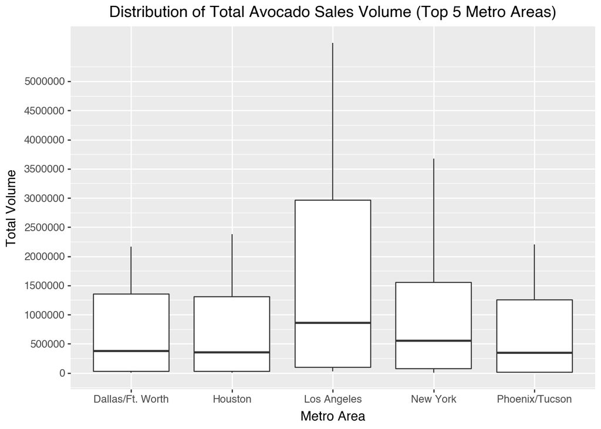

```python
from plotnine import *

top5 = ["Los Angeles", "New York", "Dallas/Ft. Worth", "Houston", "Phoenix/Tucson"]
data_top5 = data[data['geography'].isin(top5)]

(
    ggplot(data_top5, aes(x="geography", y="total_volume"))
    + geom_boxplot()
    + scale_y_continuous(breaks=range(0, 5000001, 500000))
    + labs(
        title="Distribution of Total Avocado Sales Volume (Top 5 Metro Areas)",
        x="Metro Area",
        y="Total Volume"
    )
    + theme()
)
```

## 6. From your cleaned data set, create a data set with only these California regions and answer the following questions about these California regions only.

```python
california_regions = ["Los Angeles", "San Diego", "Sacramento", "San Francisco"]

data_california = data[data['geography'].isin(california_regions)]
```

## 7. In which California regions is the price of organic versus conventional avocados most different? Support your answer with a few summary statistics AND a visualization.

```python
summary_stats = (
    data_california.groupby(['geography', 'type'])['average_price']
    .agg(['mean', 'std', 'count'])
    .reset_index()
)

print(summary_stats)
```

```
       geography          type      mean       std  count
0    Los Angeles  conventional  1.047124  0.231167    306
1    Los Angeles       organic  1.574902  0.311722    306
2     Sacramento  conventional  1.295359  0.219177    306
3     Sacramento       organic  1.873856  0.292875    306
4      San Diego  conventional  1.113856  0.242960    306
5      San Diego       organic  1.798366  0.331655    306
6  San Francisco  conventional  1.400490  0.272060    306
7  San Francisco       organic  2.119444  0.395854    306
```

```python
price_diff = summary_stats.pivot(index='geography', columns='type', values='mean')
price_diff['diff'] = price_diff['organic'] - price_diff['conventional']

print(price_diff.sort_values('diff', ascending=False))
```

```
type           conventional   organic      diff
geography
San Francisco      1.400490  2.119444  0.718954
San Diego          1.113856  1.798366  0.684510
Sacramento         1.295359  1.873856  0.578497
Los Angeles        1.047124  1.574902  0.527778
```

**San Francisco** has the largest difference in price between conventional and organic avocados. This is because the difference in mean price between the two types of avocados in San Francisco is the greatest, compared to the other California regions.

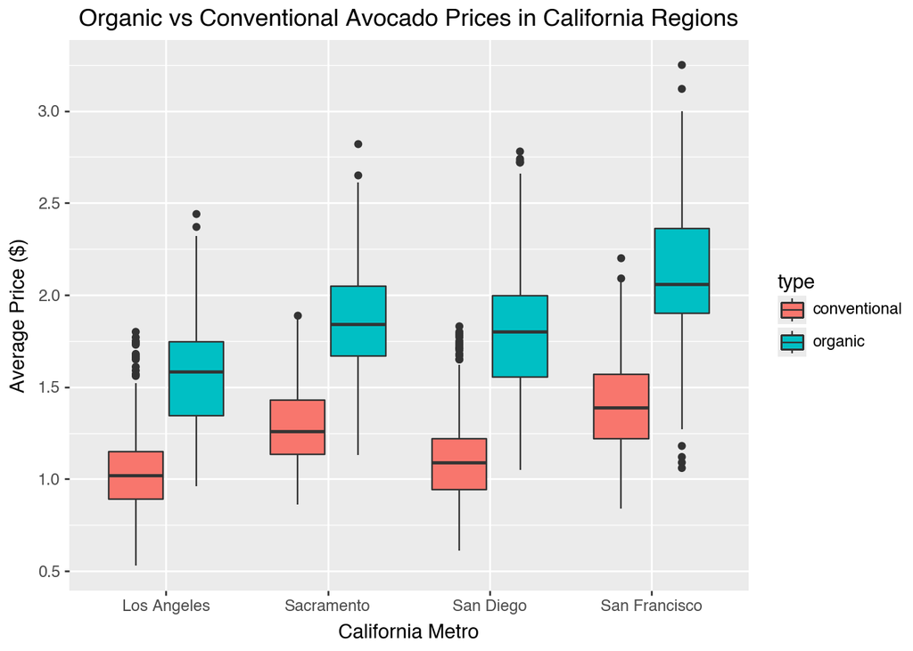

```python
from plotnine import *

(
    ggplot(data_california, aes(x="geography", y="average_price", fill="type"))
    + geom_boxplot()
    + scale_y_continuous(breaks=[0.5, 1, 1.5, 2, 2.5, 3, 3.5, 4])
    + labs(
        title="Organic vs Conventional Avocado Prices in California Regions",
        x="California Metro",
        y="Average Price ($)"
    )
    + theme()
)
```

## 8. The following plot shows, for all four California regions, the proportion of the average Hass avocado sales that are small, large, or extra large; conventional vs. organic. Recreate the plot; you do not have to replicate the exact finishing touches - e.g., color, theme - but your plot should resemble the content of this plot.

```python
data_long = data_california.melt(
    id_vars=["geography", "type"],
    value_vars=["small_hass", "large_hass", "xl_hass"],
    var_name="size",
    value_name="volume"
)

size_map = {"small_hass": "Small", "large_hass": "Large", "xl_hass": "Xlarge"}
data_long["size"] = data_long["size"].map(size_map)
```

```python
data_means = (
    data_long.groupby(["geography", "type", "size"])["volume"]
    .mean()
    .reset_index()
)

data_means["proportion"] = (
    data_means.groupby(["geography", "type"])["volume"]
    .transform(lambda x: x / x.sum()) # help from ChatGPT
)

data_proportion = data_means[["geography", "type", "size", "proportion"]]
```

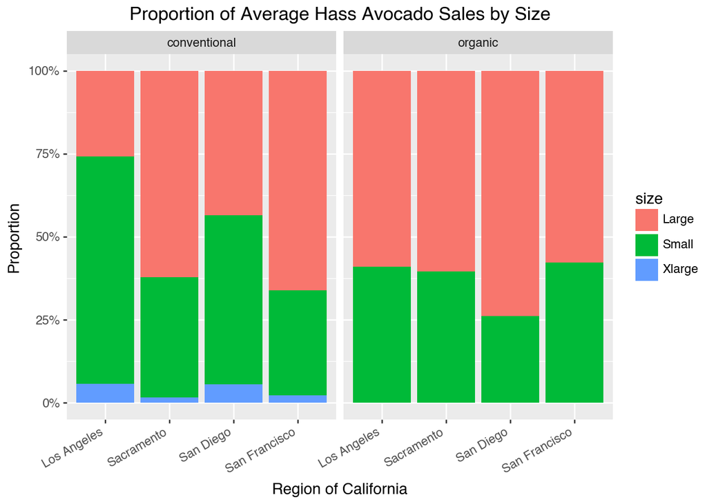

```python
from plotnine import *

(
    ggplot(data_proportion, aes(x="geography", y="proportion", fill="size"))
    + geom_bar(stat="identity", position="stack")
    + facet_wrap("~type")
    + labs(
        title="Proportion of Average Hass Avocado Sales by Size",
        x="Region of California",
        y="Proportion"
    )
    + scale_y_continuous(
    labels=["0%", "25%", "50%", "75%", "100%"], # help from ChatGPT
    breaks=[0, 0.25, 0.5, 0.75, 1.0])
    + theme(axis_text_x=element_text(rotation=30, ha="right"))
)
```

## Using Outside Data

```python
housing_data = pd.read_csv("/Users/danielkwong/Downloads/City_MedianRentalPrice_1Bedroom.csv")

housing_data = housing_data.drop(columns=["Unnamed: 0"], errors="ignore")

housing_long = housing_data.melt(
    id_vars=["RegionName", "State", "Metro", "CountyName", "SizeRank"],
    var_name="date",
    value_name="rent_price"
)

housing_long["date"] = pd.to_datetime(housing_long["date"])

ca_regions = ["Los Angeles", "San Diego", "Sacramento", "San Francisco"]
california_housing = housing_long[housing_long["RegionName"].isin(ca_regions)]

data_california["date"] = pd.to_datetime(data_california["date"])

merged = pd.merge(
    data_california,
    california_housing,
    left_on=["geography", "date"],
    right_on=["RegionName", "date"],
    how="inner"
)

print(merged.head())
```

```
        date  average_price  total_volume  small_hass  large_hass   xl_hass  \
0 2015-02-01           0.74    4031949.04  2770656.27   854673.24  64439.70
1 2015-02-01           1.12      50107.32    39628.65     1721.95      0.00
2 2015-02-01           1.04     771974.90   287292.15   429601.75  15342.47
3 2015-02-01           1.22      13195.65     7103.90     5624.41      0.00
4 2015-02-01           0.85     692276.13   357235.87   277723.14  15691.23

   total_bags  small_bags  large_bags  xlarge_bags  ... region  market_size  \
0   342179.83   308754.64    31108.07      2317.12  ...   West       Tier 1
1     8756.72     8756.72        0.00         0.00  ...   West       Tier 1
2    39738.53    39738.53        0.00         0.00  ...   West       Tier 3
3      467.34      467.34        0.00         0.00  ...   West       Tier 3
4    41625.89    36622.51     4738.29       265.09  ...   West       Tier 2

  month day   RegionName  State                                Metro  \
0     2   1  Los Angeles     CA       Los Angeles-Long Beach-Anaheim
1     2   1  Los Angeles     CA       Los Angeles-Long Beach-Anaheim
2     2   1   Sacramento     CA  Sacramento--Roseville--Arden-Arcade
3     2   1   Sacramento     CA  Sacramento--Roseville--Arden-Arcade
4     2   1    San Diego     CA                   San Diego-Carlsbad

           CountyName SizeRank rent_price
0  Los Angeles County        2     1795.0
1  Los Angeles County        2     1795.0
2   Sacramento County       30      830.0
3   Sacramento County       30      830.0
4    San Diego County        9     1710.0

[5 rows x 23 columns]
```

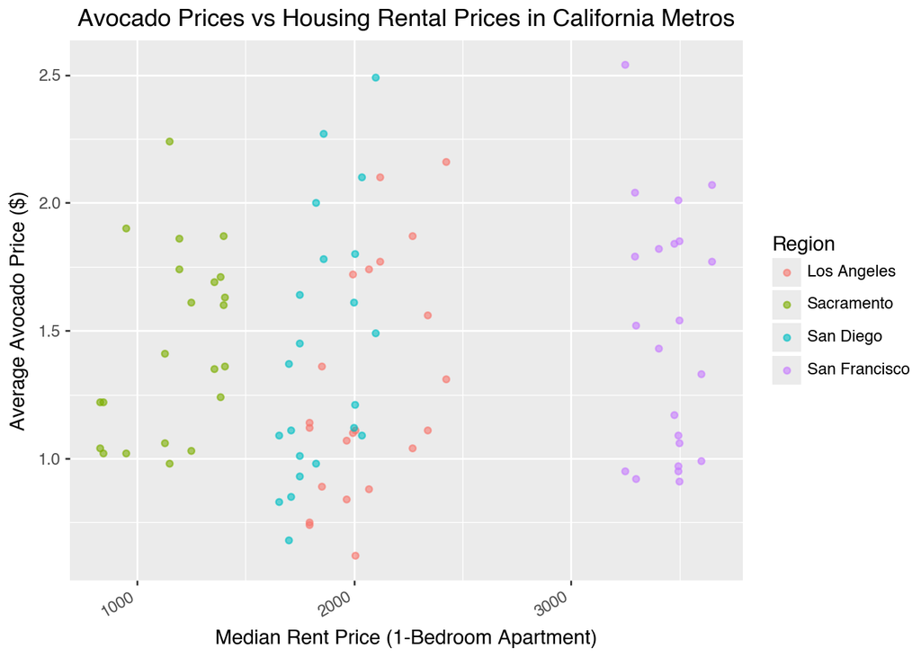

```python
from plotnine import *

(
    ggplot(merged, aes(x="rent_price", y="average_price", color="RegionName"))
    + geom_point(alpha=0.6)
    + labs(
        title="Avocado Prices vs Housing Rental Prices in California Metros",
        x="Median Rent Price (1-Bedroom Apartment)",
        y="Average Avocado Price ($)",
        color="Region"
    )
    + theme(axis_text_x=element_text(rotation=30, ha="right"))
)
```

Avocado prices fluctuate a lot week-to-week, while rent prices rise steadily over time. This means there isn’t a strong direct relationship between how much people pay for housing and how much they pay for avocados, and that the two are independent of each other. Millennials can’t afford houses simply because housing prices are rising, not because of avocado toast.